# FE680 Assignment 4

Yuxuan Xia

## Problem 1

Verify that if the CDS spread for the example in Tables (1 to 4) is 100 basis points and the probability of default in a year (conditional on no earlier default) must be 1.61%. How does the probability of default change when the recovery rate is 20% instead of 40%? Verify that your answer is consistent with the implied probability of default being approximately proportional to 1/(1-R) where R is the recovery rate.

Denote discounted factor of each year as DF,

discounted factor of each half year as $DF^*$,

survival probability as SP,

default probability as DP,

CDS spread as s.

We have the following evaluation formulas:

PV of expected payment: $$pv1 = s \Sigma_{i=1}^n DF_i SP_i $$

PV of accrued payment: $$pv2 = \frac{s}{2} \Sigma_{i=1}^n DF_{i}^* DP_i$$

PV of expected payoff: $$pv3 = (1-R) \Sigma_{i=1}^n DF^*_i DP_i$$

Risk-neutral pricing equilibrium: $$pv1+pv2-pv3 = 0$$

```python
import pandas as pd
import numpy as np
from scipy.optimize import brentq
import matplotlib.pyplot as plt
```

### Basic functions

```python
def P_survival(pd,n_years):
    res=[(1-pd)**(i+1) for i in range(n_years)]
    return res

def P_default(pd,n_years):
    p1 =[(1-pd)**(i) for i in range(n_years)]
    res = [p*pd for p in p1]
    return res

def Discounted_factor(rf,n_years):
    df = np.exp([-rf*(t+1) for t in range(n_years)])
    return df

def PV_expected_payment(DF,P_survival,spread):
    res=np.dot(DF,P_survival)*spread
    return res

def PV_accrued_payment(DF,P_default,spread):
    res = np.dot(DF,P_default)*spread*1/2
    return res

def PV_expected_payoff(DF,P_default,recovery_rate):
    res = (1-recovery_rate)*np.dot(DF,P_default)
    return res
```

```python
p_survival = P_survival(0.02,5)
p_default = P_default(0.02,5)
df1 = [0.9512,0.9048,0.8607,0.8187,0.7788]
df2 = [0.9753,0.9277,0.8825,0.8395,0.7985]
# PV_expected_payment(df1,p_survival,1)
# PV_expected_payoff(df2,p_default,0.4)
# PV_accrued_payment(df2,p_default,1)
```

```python
def CDF_price(p,s):
    p_survival = P_survival(p,5)
    p_default = P_default(p,5)
    df1 = [0.9512,0.9048,0.8607,0.8187,0.7788]
    df2 = [0.9753,0.9277,0.8825,0.8395,0.7985]
    pv1 = PV_expected_payment(df1,p_survival,s)
    pv3 = PV_expected_payoff(df2,p_default,0.4)
    pv2 = PV_accrued_payment(df2,p_default,s)
    return pv1+pv2-pv3
```

### proof the probability of default in a year (conditional on no earlier default) must be 1.61%.

```python
obj_fun = lambda p: CDF_price(p,s=0.01)
brentq(obj_fun,0,1)
```

```
0.016127100896631053
```

```python
def CDF_price_v2(p,R,s):
    p_survival = P_survival(p,5)
    p_default = P_default(p,5)
    df1 = [0.9512,0.9048,0.8607,0.8187,0.7788]
    df2 = [0.9753,0.9277,0.8825,0.8395,0.7985]
    pv1 = PV_expected_payment(df1,p_survival,s)
    pv3 = PV_expected_payoff(df2,p_default,R)
    pv2 = PV_accrued_payment(df2,p_default,s)
    return pv1+pv2-pv3
```

```python
y = lambda p: CDF_price_v2(p,R=0.4,s=0.0123)
print("default probability for one year when recovery rate equals to 0.4 is",brentq(y,0,1))
```

```
default probability for one year when recovery rate equals to 0.4 is 0.019800542345852195
```

### Verify that the implied probability of default is approximately proportional to 1/(1-R)

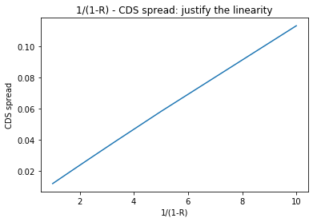

```python
s_list = []
R_list = np.linspace(0.0,0.9,10)

for R in R_list:
    obj_fun2 = lambda p: CDF_price_v2(p,R,s=0.0123)
    s_list.append(brentq(obj_fun2,0,1))

# print(s_list)
# plt.plot(R_list,s_list)
plt.plot(1/(1-np.array(R_list)),s_list)
plt.xlabel("1/(1-R)")
plt.ylabel("CDS spread")
plt.title("1/(1-R) - CDS spread: justify the linearity")
plt.show()
```

## Problem 2

Suppose that the risk-free zero curve is flat at 6% per annum with continuous compounding and that defaults can occur at times 0.25 years, 0.75 years, 1.25 years, and 1.75 years in a two-year plain vanilla credit default swap with semiannual payments. Suppose that the recovery rate is 20% and the unconditional probabilities of default (as seen at time zero) are 1% at times 0.25 years and 0.75 years, and 1.5% at times 1.25 years and1.75 years. What is the credit default swap spread? What would the credit default spread be if the instrument were a binary credit default swap?

Similar to problem 1, only difference is here, we have our payment interval not annually but semiannually, so we should introduce time interval fraction denoted as $\alpha$

### Assumption about default dates

Assume the defaults only occur semiannually, say, [0.25,0.75,1.25,1.75]

denote discounted factor of each payment date([0.5,1,1.5,2]) as DF,

denote discounted factor of each half year([0.5,1,1.5,2]) as $DF^*$,

### Assumption about default dates (*please check this*)

denote discounted factor of each payment date([0.25,0.75,1.25,1.75]) as DF,

denote discounted factor of each half year([0,0.5,1,1.5]) as $DF^*$,

survival probability as SP,

default probability as DP,

CDS spread as s.

We have the following evaluation formulas:

PV of expected payment: $$pv1 = s \Sigma_{i=1}^n \alpha_i DF_i SP_i $$

PV of accrued payment: $$pv2 = \frac{s}{2} \Sigma_{i=1}^n \alpha_i DF_{i}^* DP_i$$

PV of expected payoff: $$pv3 = (1-R) \Sigma_{i=1}^n DF^*_i DP_i$$

Still, we have risk-neutral pricing equilibrium: $$pv1+pv2-pv3 = 0$$